# Prediction of Quality of Execution in a Weight Lifting Exercise

Andrea Schioppa

We train a Machine Learning algorithm to predict how well participants in a weight lifting experiment performed the exercises. The data is available from the website (http://groupware.les.inf.puc-rio.br/har) (see the section on the Weight Lifting Exercise Dataset). The paper is: Velloso, E.; Bulling, A.; Gellersen, H.; Ugulino, W.; Fuks, H. Qualitative Activity Recognition of Weight Lifting Exercises. Proceedings of 4th International Conference in Cooperation with SIGCHI (Augmented Human ’13) . Stuttgart, Germany: ACM SIGCHI, 2013.

We assume that the data is downloaded in the current directory in the file `pml-training.csv`.

# Cleaning the Data

We load the required libraries.

```r
library(ggplot2);
library(caret);
```

We load the training data.

```r
data.train <- read.csv('pml-training.csv', header=TRUE);
```

We remove the first column which is just the row number. Some predictors consist of a large fraction of `NA`s and so we remove them.

```r
data.train <- data.train[,-1];

na.predictors <- c();

for(i in 1:length(names(data.train))) {
    if(mean(is.na(data.train[,i]))>0.90)
        na.predictors <- c(na.predictors,i);
}

data.train <- data.train[,-na.predictors];
```

The predictor `cvtd_timestamp` is a kind of time stamp which has been read as `character`, and we convert it to a numeric format using the `POSIXct` standard.

```r
data.train$cvtd_timestamp <- strptime(data.train$cvtd_timestamp, format='%d/%m/%Y %H:%M');
data.train$cvtd_timestamp <- as.numeric(as.POSIXct(data.train$cvtd_timestamp));
```

There are also other predictors which contain many missing values. They were not eliminated previously, because they show as factors; we now remove them:

```r
na.predictors <- c();

for(i in 2:(length(names(data.train))-1)) {
    if(class(data.train[,i])=='factor') {
    if(mean(as.character(data.train[,i])=="")>0.90) {
        na.predictors <- c(na.predictors,i);
    }
   }
}

data.train <- data.train[,-na.predictors];
```

We finally convert to `numeric` predictors that were read as `integers`.

```r
for(i in 1:length(names(data.train))) {
    if(class(data.train[,i])=='integer') {
        data.train[,i] <- as.numeric(data.train[,i]);
    }
}
```

# Choice of Predictors

The cleaned data frame `data.train` contains now 59 columns, 58 of which are predictors, and the last one is the variable `classe` which has to be predicted. We now split the data set into a train and test part. Note that as we are going to fit a Random Forest, this is not necessary (http://www.stat.berkeley.edu/~breiman/RandomForests/cc_home.htm#ooberr) (in the Coursera Lectures I found this point confusing), but we do create a test set to compare the out of sample error on the test set with the error predicted by the training.

```r
set.seed(125);

split.indx <- createDataPartition(data.train$classe, p = 0.8, list = FALSE);
data.test <- data.train[-split.indx, ]
data.train <- data.train[split.indx, ]
```

The variables `cvtd_timestamp` and `raw_timestamp_part_1` are almost perfectly correlated.

```r
cor(data.train$cvtd_timestamp, data.train$raw_timestamp_part_1)
```

```
## [1] 1
```

We illustrate this with a plot.

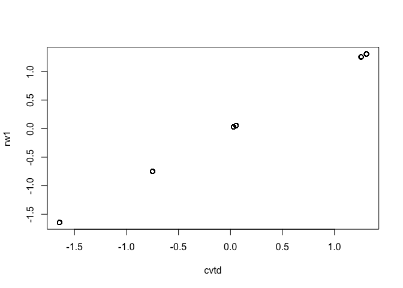

```r
timestamps <- data.frame(cvtd = data.train$cvtd_timestamp, rw1 = data.train$raw_timestamp_part_1);
preproc.tsmp <- preProcess(timestamps, method = c('center', 'scale'));
timestamps <- predict(preproc.tsmp, timestamps)
with(timestamps, plot(cvtd, rw1));
```

Another plot shows that the other time stamp variable `raw_timestamp_part_2` is rather homogeneous among the different classes.

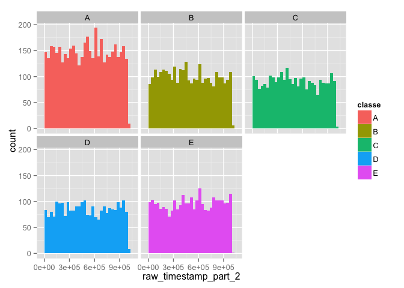

```r
tmsp.plot <- ggplot(data.train, aes(x=raw_timestamp_part_2, fill=classe, y = ..count..));
tmsp.plot <- tmsp.plot
tmsp.plot + geom_histogram() + facet_wrap(~classe);
```

Overall, the timestamps are variables which to do not seem to have much predictive value, so we remove them. We also remove `num_window` which keeps track of the number of the window in which the measures were taken.

```r
toremove <- c('raw_timestamp_part_1', 'raw_timestamp_part_2', 'cvtd_timestamp', 'num_window');
data.train <- data.train[,-which(names(data.train) %in% toremove)];
data.test <- data.test[,-which(names(data.test) %in% toremove)];
```